# Analysis of Bikeshare Data with chatGPT

# Introduction

The purpose of this analysis is to use chatGPT as an assistant to produce a predictive model for the bikeshare dataset. First we will import the Bikeshare dataset into R as well as load packages for analysis.

```r
library(tidyverse)
library(here)
library(knitr)
data <- read_csv(here("inputs\\day.csv"))
```

# Data Exploration

We can do some preliminary analysis of the data to see if particular models may be more appropriate then others.

We have some categorical variables in weathersit, which has 4 factors based on worsening weather conditions from clear, to mist, to light snow/rain, to heavy snow/rain. And we have a season variable indicating the 4 different seasons.

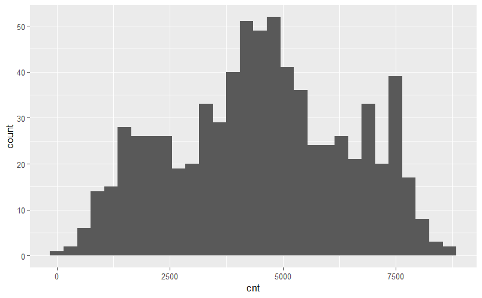

```r
data %>%
  ggplot(aes(x = cnt)) + geom_histogram()
```

The response in this case is a count of bicycles rented for the day. Count data is most often represented by a poisson or negative/positive binomial distribution. The difference between these 2 distributions is that poisson regression is used for count where the mean is roughly equal to the standard deviation. We check to see whether this holds for the bikeshare data.

```r
data$cnt %>% sd()
data$cnt %>% mean()
```

[output not shown]

```r
data %>%
  ggplot(aes(sample = cnt))+stat_qq(distribution = stats::qpois, dparams = list(lambda = mean(data$cnt)))+ stat_qq_line(distribution = stats::qpois, dparams = list(lambda = mean(data$cnt))) +
  ylab("Data Quantiles") +
  xlab("Poisson Quantiles") +
  theme(axis.title.y = element_text(size = rel(1.5), angle = 90)) +
  theme(axis.title.x = element_text(size = rel(1.5), angle = 00))
```

[output not shown]

# Model Building

First we can try a basic 80/20 validation and test split and fit the full poisson regression model. We make slight adjustments to the features to ensure dates are encoded as datetime objects and remove variables like instant which just refer to the observation number. Then compute the mean absolute and mean square errors on the test data.

```r
# Convert date to Date type
data$date <- as.Date(data$dteday)

# Remove unnecessary columns
data <- data %>% dplyr::select(-instant, -dteday, -casual, -registered)
```

```r
# Split the data into training and testing sets
set.seed(42)
train_indices <- sample(1:nrow(data), size = 0.8 * nrow(data))
train_data <- data[train_indices,]
test_data <- data[-train_indices,]

# Fit Poisson regression model
model <- glm(cnt ~ ., data = train_data, family = poisson())
summary(model)
```

```
Call:
glm(formula = cnt ~ ., family = poisson(), data = train_data)

Deviance Residuals:
    Min       1Q   Median       3Q      Max
-86.451   -8.752    0.760    9.551   45.442

Coefficients:
              Estimate Std. Error z value Pr(>|z|)
(Intercept)  4.183e+01  1.063e+00   39.36   <2e-16 ***
season       1.222e-01  1.240e-03   98.51   <2e-16 ***
yr           1.300e+00  2.600e-02   50.01   <2e-16 ***
mnth         6.349e-02  2.173e-03   29.22   <2e-16 ***
holiday     -1.826e-01  4.220e-03  -43.26   <2e-16 ***
weekday      1.331e-02  3.126e-04   42.58   <2e-16 ***
workingday   1.514e-02  1.369e-03   11.06   <2e-16 ***
weathersit  -1.691e-01  1.585e-03 -106.72   <2e-16 ***
temp         3.314e-01  2.351e-02   14.10   <2e-16 ***
atemp        9.608e-01  2.681e-02   35.84   <2e-16 ***
hum         -6.570e-02  6.223e-03  -10.56   <2e-16 ***
windspeed   -4.856e-01  8.887e-03  -54.65   <2e-16 ***
date        -2.292e-03  7.105e-05  -32.25   <2e-16 ***
---
Signif. codes:  0 ‘***’ 0.001 ‘**’ 0.01 ‘*’ 0.05 ‘.’ 0.1 ‘ ’ 1

(Dispersion parameter for poisson family taken to be 1)

    Null deviance: 523966  on 583  degrees of freedom
Residual deviance: 134892  on 571  degrees of freedom
AIC: 140834

Number of Fisher Scoring iterations: 4
```

```r
# Make predictions
test_data$pred_count <- predict(model, newdata = test_data, type = "response")

# Calculate mean absolute error (MAE)
mae <- mean(abs(test_data$cnt - test_data$pred_count))
cat("Mean Absolute Error (MAE):", mae, "\n")
```

```
Mean Absolute Error (MAE): 670.8531
```

```r
# Calculate root mean squared error (RMSE)
rmse <- sqrt(mean((test_data$cnt - test_data$pred_count)^2))
cat("Root Mean Squared Error (RMSE):", rmse, "\n")
```

```
Root Mean Squared Error (RMSE): 876.5497
```

Next we will do some additional feature engineering. We will encode the datetime as a cyclical variable using sine and cosine functions. This will establish that for instance January is closer to December then it is to April.

```r
train_data$mnth_sin <- sin(2 * pi * train_data$mnth / 12)
train_data$mnth_cos <- cos(2 * pi * train_data$mnth / 12)

train_data$weekday_sin <- sin(2 * pi * train_data$weekday / 7)
train_data$weekday_cos <- cos(2 * pi * train_data$weekday / 7)

test_data$mnth_sin <- sin(2 * pi * test_data$mnth / 12)
test_data$mnth_cos <- cos(2 * pi * test_data$mnth / 12)

test_data$weekday_sin <- sin(2 * pi * test_data$weekday / 7)
test_data$weekday_cos <- cos(2 * pi * test_data$weekday / 7)
```

```r
# Creating a dataframe containing residuals and fitted values
df <- broom::augment(model)

# Residuals vs. fitted values plot
ggplot(df, aes(x = .fitted, y = .resid/sqrt(.fitted))) +
  geom_point(alpha = 0.5) +
  geom_hline(yintercept = 0, linetype = "dashed") +
  labs(title = "Residuals vs. Fitted Values", x = "Fitted Values", y = "Pearson Residuals")

# Residuals vs. continuous predictors
resid.check <- function(data, mapping) {
  ggplot(data, mapping) +
    geom_point(alpha = 0.5) +
    geom_hline(yintercept = 0, linetype = "dashed") +
    labs(title = "Residuals Plot", x = "", y = "Pearson Residuals") +
    geom_smooth()
}
resid.check(df, aes(x = temp, y = .resid/sqrt(.fitted)))
resid.check(df, aes(x = hum, y = .resid/sqrt(.fitted)))
resid.check(df, aes(x = windspeed, y = .resid/sqrt(.fitted)))
```

[output not shown]

We check our continuous predictors and find a definite pattern within the temp predictor, suggesting there is a relationship not being captured by the model. We can adjust for this by adding transformations of temp.

```r
cat("Root Mean Squared Error (RMSE):", rmse, "\n")
```

[output not shown]

```r
df <- broom::augment(model)
resid.check(df, aes(x = temp, y = .resid/sqrt(.fitted)))
```

[output not shown]

Now we get a much more randomly scattered plot of the residuals after the transformation. We can add these additional predictors directly into the dataset

```r
train_data <- train_data %>% dplyr::mutate(temp_2 = temp^2, temp_3 = temp^3)
test_data <- test_data %>% dplyr::mutate(temp_2 = temp^2, temp_3 = temp^3)
```

We may try lasso regression as a method for variable selection.

```r
# Splitting train and test sets for glmnet()
set.seed(1)
test_data <- test_data %>% dplyr::select(-pred_count)
X <- model.matrix(cnt ~ . -1, data = train_data)
X.test <- model.matrix(cnt ~ . -1, data = test_data)
Y <- train_data$cnt
Y.test <- test_data$cnt
# Fit LASSO model
lasso <- glmnet(X, Y, family = "poisson" , alpha = 1)
# Cross Validating lambda values
lasso.cv <- cv.glmnet(X, Y, family = "poisson", alpha = 1)
# Finding optimal lambda
optimal <- lasso.cv$lambda.min
# Fit the optimal lambda model
lasso.mod <- glmnet(X, Y, family = "poisson", alpha = 1, lambda = optimal)

# Make predictions
lasso.pred <- predict(lasso, optimal, newx = X.test)

sqrt(mean((lasso.pred-Y.test)^2))
```

[output not shown]

We see a rather large increase in RMSE in this case, suggesting that our original model is not overfitting, however we can check this via cross-validation.

```r
sqrt(mean(cv.error.10))
```

[output not shown]

```
[1] 699.7569
```